# Forecasting Brazilian Inflation (IPCA) with LASSO and Elastic Net

BIC tuning, strong benchmarks, and a time-respecting pseudo-out-of-sample evaluation

Pedro Bragança

September 04, 2026

# 1 Objective and study design

This document addresses a classic question in the inflation-forecasting literature: **does a regularized model with many predictors beat naïve benchmarks and the market consensus at forecasting monthly Brazilian inflation (the IPCA)?**

The workflow follows a time-series forecasting protocol inspired by *Araujo & Gaglianone, Banco Central do Brasil Working Paper 561, 2022*:

1. Data collection from official public APIs (Banco Central do Brasil / SGS and the Focus market-expectations survey);
2. Inspection, stationarity, and seasonality;
3. Transformations consistent with a forecasting exercise;
4. LASSO and Elastic Net with hyperparameters chosen by **BIC**, avoiding random K-fold on time-ordered data;
5. A **pseudo-out-of-sample** evaluation over an expanding window;
6. Comparison against a Random Walk, Atkeson–Ohanian, a seasonal naïve rule, an ARMA, and the **Focus** median — across four horizons (1, 3, 6, 12 months);
7. RMSE/MAE, Diebold–Mariano tests, cumulative squared-error gain, and a recursive analysis of variable selection and importance.

> **Scope.** This is a personal, fully reproducible methodological study built entirely on public data. It is a *retrospective forecast-evaluation exercise* — not a forecast of future inflation, and not an official projection of any institution. Coefficients measure predictive power, not causal effects.

## 1.1 Packages

```r
pkgs <- c("httr","jsonlite","dplyr","tidyr","lubridate","ggplot2",
          "glmnet","forecast","tseries","urca","zoo","knitr","scales",
          "sandwich","lmtest","car","stringr","purrr")
missing <- setdiff(pkgs, rownames(installed.packages()))
if (length(missing)) install.packages(missing, repos = "https://cloud.r-project.org")
invisible(lapply(pkgs, library, character.only = TRUE))

# study palette
COR <- list(azul="#2563a8", claro="#4fa3e0", verde="#1e8449",
            cinza="#7a9bbf", vermelho="#c0392b", tinta="#0f2942")
theme_set(theme_minimal(base_size = 12) +
  theme(panel.grid.minor = element_blank(),
        plot.title = element_text(face = "bold", color = COR$tinta),
        plot.subtitle = element_text(color = "grey30")))
```

# 2 Data collection via API (BCB/SGS)

The Time Series Management System (SGS) of the Banco Central do Brasil exposes each series at `https://api.bcb.gov.br/dados/serie/bcdata.sgs.{code}/dados`. The response is JSON with dates in `dd/mm/yyyy` and comma decimal separators.

```r
# Download one SGS series and return a monthly tibble (date, value).
fetch_sgs <- function(code, start = "01/01/2004") {
  url <- sprintf(
    "https://api.bcb.gov.br/dados/serie/bcdata.sgs.%s/dados?formato=json&dataInicial=%s",
    code, start)
  resp <- httr::GET(url, httr::timeout(60), httr::add_headers(`Accept-Encoding` = "gzip"))
  stopifnot(httr::status_code(resp) == 200)
  dat <- jsonlite::fromJSON(httr::content(resp, "text", encoding = "UTF-8"))
  tibble::tibble(
    date  = lubridate::dmy(dat$data),
    value = as.numeric(gsub(",", ".", dat$valor))
  ) |>
    dplyr::mutate(date = lubridate::floor_date(date, "month")) |>
    dplyr::filter(!is.na(date), is.finite(value)) |>
    dplyr::arrange(date)
}
```

The series retrieved are:

- IPCA — monthly change (target);
- BRL/USD exchange rate (sell, end of period);
- Selic policy rate (accumulated in the month, annualized);
- IGP-M — FGV (% per month);
- IPCA core — trimmed means with smoothing (% per month).

```r
# Catalog of series: target (IPCA) + macro predictors.
catalogo <- tibble::tribble(
  ~id,       ~code,   ~label,                                     ~unit,
  "ipca",    "433",   "IPCA — monthly change",                    "% m/m",
  "cambio",  "3698",  "BRL/USD (sell, end of period)",            "BRL/USD",
  "selic",   "4189",  "Selic (accumulated in month, annualized)", "% p.a.",
  "igpm",    "189",   "IGP-M — FGV",                              "% m/m",
  "nucleo",  "4466",  "IPCA core — trimmed means (smoothed)",     "% m/m"
)
knitr::kable(catalogo, caption = "Series used (source: BCB/SGS).")
```

Series used (source: BCB/SGS).

| id | code | label | unit |
| --- | --- | --- | --- |
| ipca | 433 | IPCA — monthly change | % m/m |
| cambio | 3698 | BRL/USD (sell, end of period) | BRL/USD |
| selic | 4189 | Selic (accumulated in month, annualized) | % p.a. |
| igpm | 189 | IGP-M — FGV | % m/m |
| nucleo | 4466 | IPCA core — trimmed means (smoothed) | % m/m |

```r
# Download all catalog series. If the API is unavailable, read/write a local
# cache to keep the knit reproducible.
cache_file <- "dados_sgs_cache.rds"
series <- tryCatch({
  s <- lapply(catalogo$code, fetch_sgs)
  names(s) <- catalogo$id
  saveRDS(s, cache_file); s
}, error = function(e) {
  message("API unavailable — using local cache: ", conditionMessage(e))
  readRDS(cache_file)
})

# Aligned monthly panel (levels).
painel <- Reduce(function(a, b) dplyr::full_join(a, b, by = "date"),
  Map(function(s, nm) dplyr::rename(s, !!nm := value), series, names(series))) |>
  dplyr::arrange(date)

tail(painel, 6)
```

| date | ipca | cambio | selic | igpm | nucleo |
| --- | --- | --- | --- | --- | --- |
| 2026-04-01 | 0.67 | 5.0331 | 14.64 | 2.73 | 0.48 |
| 2026-05-01 | 0.58 | 4.9837 | 14.40 | 0.84 | 0.43 |
| 2026-06-01 | 0.16 | 5.1276 | 14.29 | -0.50 | 0.24 |
| 2026-07-01 | 0.07 | 5.1139 | 14.15 | -1.16 | 0.29 |
| 2026-08-01 | NA | NA | 13.94 | -0.22 | NA |
| 2026-09-01 | NA | NA | 13.90 | NA | NA |

## 2.1 Market expectations (Focus survey, Olinda API)

The most demanding benchmark for Brazilian inflation is the **median of the Focus survey expectations**. It is not in the SGS but in the Market Expectations API (Olinda/OData). For each survey date and each **reference month**, we extract the median IPCA expectation. In the backtest, the Focus forecast for a target is the **most recent median known at the origin** (a survey dated on or before the origin) for that reference month — respecting the same information set as the other models.

```r
# Download the median of monthly Focus IPCA expectations (baseCalculo = 0,
# 30-day window). Source: BCB / Market Expectations (Olinda OData).
fetch_focus_ipca <- function(start = "2010-01-01") {
  base <- paste0("https://olinda.bcb.gov.br/olinda/servico/Expectativas/",
                 "versao/v1/odata/ExpectativaMercadoMensais")
  filtro <- sprintf(
    "Indicador eq 'IPCA' and baseCalculo eq 0 and Data ge '%s'", start)
  url <- paste0(
    base, "?$top=1000000&$format=json&$select=Data,DataReferencia,Mediana",
    "&$filter=", utils::URLencode(filtro, reserved = TRUE))
  resp <- httr::GET(url, httr::timeout(120),
                    httr::add_headers(`Accept-Encoding` = "gzip"))
  stopifnot(httr::status_code(resp) == 200)
  dat <- jsonlite::fromJSON(httr::content(resp, "text", encoding = "UTF-8"))$value
  tibble::tibble(
    survey_date = as.Date(dat$Data),
    ref_month   = lubridate::dmy(paste0("01/", dat$DataReferencia)),
    mediana     = as.numeric(dat$Mediana)
  ) |>
    dplyr::filter(!is.na(survey_date), !is.na(ref_month), is.finite(mediana)) |>
    dplyr::arrange(ref_month, survey_date)
}

focus_cache <- "focus_ipca_cache.rds"
focus <- tryCatch({
  f <- fetch_focus_ipca()
  saveRDS(f, focus_cache); f
}, error = function(e) {
  message("Focus API unavailable — using local cache: ", conditionMessage(e))
  readRDS(focus_cache)
})

# Focus expectation for the target month, as known at the origin.
focus_forecast <- function(origin_date, target_date, focus_df = focus) {
  cand <- focus_df[focus_df$ref_month == target_date &
                     focus_df$survey_date <= origin_date, ]
  if (nrow(cand) == 0) return(NA_real_)
  cand$mediana[which.max(cand$survey_date)]
}

cat(sprintf("Focus: %d observations | %s to %s\n",
            nrow(focus), format(min(focus$ref_month), "%b %Y"),
            format(max(focus$ref_month), "%b %Y")))
```

```
## Focus: 84964 observations | Dec 2009 to Aug 2028
```

```r
# Cross-check against known IPCA prints (integrity check).
checagem <- tibble::tibble(
  date = as.Date(c("2015-01-01","2020-04-01","2022-03-01","2022-07-01")),
  expected = c(1.24, -0.31, 1.62, -0.68)) |>
  dplyr::left_join(dplyr::select(painel, date, ipca), by = "date") |>
  dplyr::mutate(ok = abs(ipca - expected) < 1e-9)
knitr::kable(checagem, caption = "IPCA integrity check.")
```

IPCA integrity check.

| date | expected | ipca | ok |
| --- | --- | --- | --- |
| 2015-01-01 | 1.24 | 1.24 | TRUE |
| 2020-04-01 | -0.31 | -0.31 | TRUE |
| 2022-03-01 | 1.62 | 1.62 | TRUE |
| 2022-07-01 | -0.68 | -0.68 | TRUE |

```r
stopifnot(all(checagem$ok))
```

# 3 Inspection and visualization

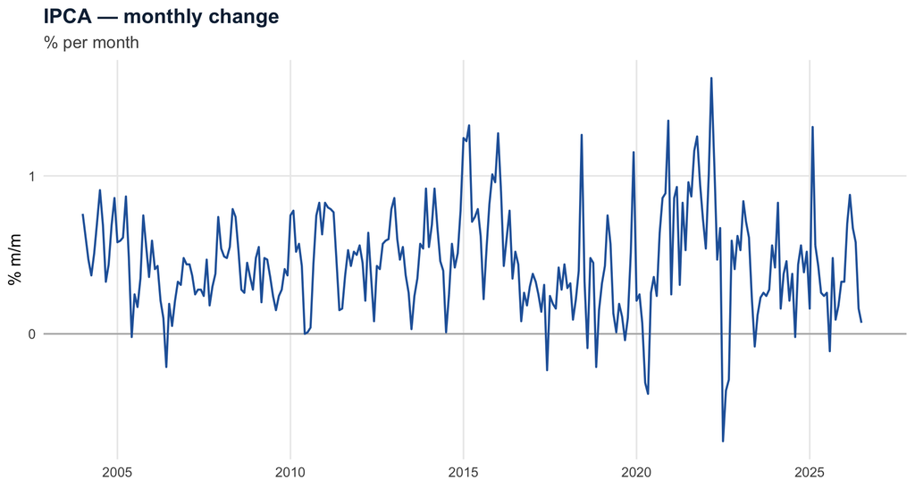

```r
p_ipca <- ggplot(painel, aes(date, ipca)) +
  geom_hline(yintercept = 0, color = "grey70") +
  geom_line(color = COR$azul, linewidth = 0.7) +
  labs(title = "IPCA — monthly change", subtitle = "% per month",
       x = NULL, y = "% m/m")
print(p_ipca)
```

```r
ggsave("assets_en/fig1_ipca.png", p_ipca, width = 9, height = 4.8, dpi = 160)
```

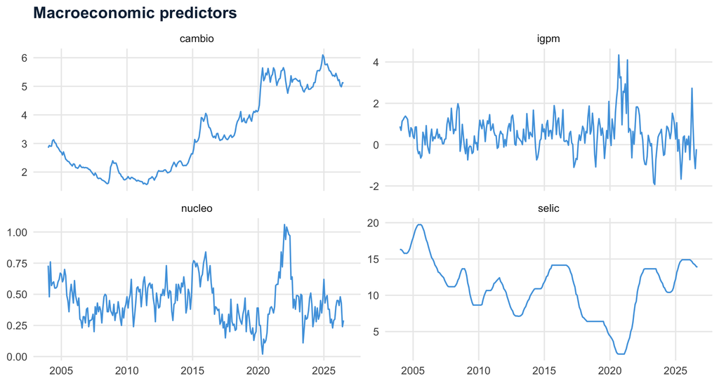

```r
painel |>
  tidyr::pivot_longer(-date) |>
  dplyr::filter(name %in% c("cambio","selic","igpm","nucleo")) |>
  ggplot(aes(date, value)) +
  geom_line(color = COR$claro, linewidth = 0.6) +
  facet_wrap(~name, scales = "free_y") +
  labs(title = "Macroeconomic predictors", x = NULL, y = NULL)
```

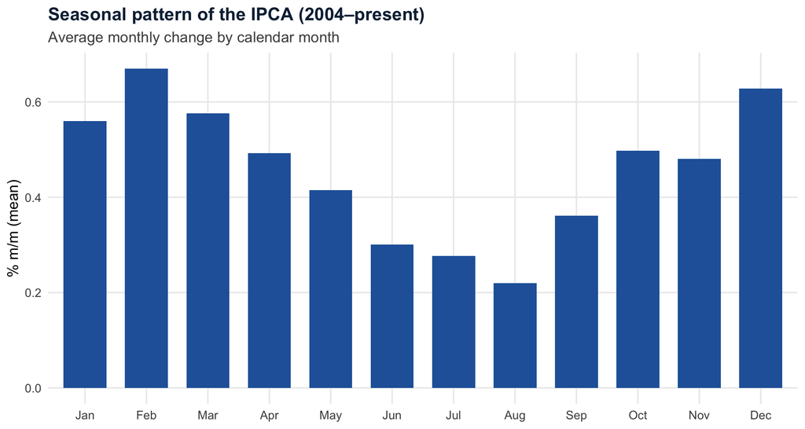

```r
# Seasonal profile of the IPCA: mean by calendar month.
p_sazonal <- painel |>
  dplyr::mutate(mes = lubridate::month(date, label = TRUE)) |>
  dplyr::group_by(mes) |>
  dplyr::summarise(media = mean(ipca, na.rm = TRUE), .groups = "drop") |>
  ggplot(aes(mes, media)) +
  geom_col(fill = COR$azul, width = 0.7) +
  labs(title = "Seasonal pattern of the IPCA (2004–present)",
       subtitle = "Average monthly change by calendar month",
       x = NULL, y = "% m/m (mean)")
print(p_sazonal)
```

```r
ggsave("assets_en/fig2_sazonal.png", p_sazonal, width = 9, height = 4.8, dpi = 160)
```

# 4 Hypotheses and their testing

Choosing the specification requires checking, before estimating, the order of integration and the seasonality of the series. We use **tests with opposite null hypotheses** (ADF/PP vs. KPSS) to reduce misclassification.

> **H1.** Monthly IPCA is stationary in levels — $I(0)$. **H2.** There is deterministic monthly seasonality in the IPCA. **H3.** The exchange rate in levels is $I(1)$; its log change is $I(0)$. For the policy rate, the forecasting exercise uses the first difference of the Selic. **H4.** (central hypothesis) regularized models achieve lower out-of-sample error than naïve benchmarks and an ARMA benchmark.

```r
test_stac <- function(x, name) {
  x <- na.omit(x)
  adf  <- suppressWarnings(tseries::adf.test(x))       # H0: unit root
  pp   <- suppressWarnings(tseries::pp.test(x))        # H0: unit root
  kpss <- suppressWarnings(tseries::kpss.test(x, null = "Level")) # H0: stationary
  tibble::tibble(
    series = name,
    ADF_p  = round(adf$p.value, 3),
    PP_p   = round(pp$p.value, 3),
    KPSS_p = round(kpss$p.value, 3),
    conclusion = dplyr::case_when(
      adf$p.value < 0.05 & kpss$p.value > 0.05 ~ "I(0) — stationary",
      adf$p.value > 0.05 & kpss$p.value < 0.05 ~ "I(1) — non-stationary",
      TRUE ~ "ambiguous — inspect")
  )
}

cambio_dlog <- diff(log(painel$cambio)) * 100

res_testes <- dplyr::bind_rows(
  test_stac(painel$ipca,   "IPCA (level)"),
  test_stac(painel$nucleo, "Core (level)"),
  test_stac(painel$igpm,   "IGP-M (level)"),
  test_stac(painel$cambio, "Exchange rate (level)"),
  test_stac(cambio_dlog,   "Exchange rate (log change %)"),
  test_stac(painel$selic,  "Selic (level)")
)
knitr::kable(res_testes, caption = "Unit-root tests (p-values).")
```

Unit-root tests (p-values).

| series | ADF_p | PP_p | KPSS_p | conclusion |
| --- | --- | --- | --- | --- |
| IPCA (level) | 0.010 | 0.010 | 0.10 | I(0) — stationary |
| Core (level) | 0.070 | 0.010 | 0.10 | ambiguous — inspect |
| IGP-M (level) | 0.010 | 0.010 | 0.10 | I(0) — stationary |
| Exchange rate (level) | 0.138 | 0.637 | 0.01 | I(1) — non-stationary |
| Exchange rate (log change %) | 0.010 | 0.010 | 0.10 | I(0) — stationary |
| Selic (level) | 0.283 | 0.818 | 0.01 | I(1) — non-stationary |

**Reading.** IPCA, core, and IGP-M are evaluated in levels; the exchange rate enters the model in **log change**, not in levels. For the Selic, the forecasting exercise uses the **first difference**, avoiding mixing the level and the change of the same rate and keeping a transformation comparable to the one used in central-bank forecasting exercises. The unit-root tests serve as a specification diagnostic, not as a mechanical predictor-selection rule.

```r
# H2: deterministic seasonality in the IPCA.
df_saz <- painel |>
  dplyr::filter(!is.na(ipca)) |>
  dplyr::mutate(mes = factor(lubridate::month(date)))

mod_saz  <- lm(ipca ~ mes, data = df_saz)
mod_null <- lm(ipca ~ 1,   data = df_saz)

test_F <- anova(mod_null, mod_saz)
cat(sprintf("Classical F-test: F = %.2f, p = %.4g\n",
            test_F$F[2], test_F$`Pr(>F)`[2]))
```

```
## Classical F-test: F = 5.12, p = 2.938e-07
```

```r
# Robustness to autocorrelation/heteroskedasticity: joint HAC/Newey-West test.
V_hac <- sandwich::NeweyWest(mod_saz, lag = 12,
                             prewhite = FALSE, adjust = TRUE)
test_HAC <- car::linearHypothesis(
  mod_saz,
  car::matchCoefs(mod_saz, "mes"),
  vcov. = V_hac,
  test = "F"
)
print(test_HAC)
```

```
##
## Linear hypothesis test:
## mes2 = 0
## mes3 = 0
## mes4 = 0
## mes5 = 0
## mes6 = 0
## mes7 = 0
## mes8 = 0
## mes9 = 0
## mes10 = 0
## mes11 = 0
## mes12 = 0
##
## Model 1: restricted model
## Model 2: ipca ~ mes
##
## Note: Coefficient covariance matrix supplied.
##
##   Res.Df Df      F         Pr(>F)
## 1    270
## 2    259 11 6.4652 0.000000001732 ***
## ---
## Signif. codes:  0 '***' 0.001 '**' 0.01 '*' 0.05 '.' 0.1 ' ' 1
```

Seasonality is considered relevant when the joint hypothesis that the monthly dummies are zero is rejected. The HAC test is reported as the main robustness check for inference on monthly data.

# 5 The models and their equations

## 5.1 Benchmarks

**Random Walk (no-change).**

$$\hat{\pi}_{t+1|t}^{RW} = \pi_t$$

**Atkeson–Ohanian (RW-AO).** For monthly IPCA, we use the average of the last 12 monthly changes:

$$\hat{\pi}_{t+1|t}^{AO} =
\frac{1}{12}\sum_{j=0}^{11}\pi_{t-j}.$$

**Seasonal naïve.** The forecast is inflation in the same month of the previous year:

$$\hat{\pi}_{t+1|t}^{SN} = \pi_{t-11}.$$

**ARMA.** At each backtest origin, an ARMA is selected using only the history available up to $t$, by BIC. For horizon $h$, we take the $h$-step-ahead forecast. This benchmark adds a traditional econometric reference to the horse race.

**Focus (median).** For Brazilian inflation, the *de facto* benchmark is the median of the Focus market expectations. For a target in month $m$, we use the most recent median known at origin $t$ for reference month $m$. Beating — or even matching — the Focus is a far harder test than beating a Random Walk, and it is the comparison a practitioner looks for first.

## 5.2 Penalized regression

Let $x_t$ be the vector of predictors available at origin $t$. LASSO solves

$$\hat{\beta}^{LASSO} = \arg\min_{\beta}\
\frac{1}{2n}\sum_t
(\pi_{t+1}-x_t'\beta)^2 + \lambda\sum_j|\beta_j|.$$

Elastic Net adds the $\ell_2$ penalty:

$$\hat{\beta}^{EN} = \arg\min_{\beta}\
\frac{1}{2n}\sum_t
(\pi_{t+1}-x_t'\beta)^2 + \lambda\left[\alpha\sum_j|\beta_j| +
\frac{1-\alpha}{2}\sum_j\beta_j^2\right].$$

### 5.2.1 BIC tuning

Instead of random K-fold, which breaks the chronological ordering of the observations, we select $\lambda$ — and, for Elastic Net, the pair $(\lambda,\alpha)$ — by the **Bayesian Information Criterion** within each training window:

$$BIC(\lambda,\alpha) =
n\log\left(\frac{RSS}{n}\right) + k\log(n),$$

where $k$ is the number of non-zero coefficients plus the intercept. This way, no information after the forecast origin participates in the tuning.

### 5.2.2 Direct multi-horizon forecasting

We evaluate $h \in \{1, 3, 6, 12\}$ months via the **direct** approach: for each horizon, the model regresses $\pi_{t+h}$ directly on the information set available at $t$ (lags $0\!-\!11$ of the macro blocks plus the dummy for the target month $t+h$). There is no forecast iteration, which avoids error accumulation and keeps each horizon with its own BIC tuning. At one month, inertia tends to dominate and the naïve benchmarks are hard to beat; it is at the longer horizons that regularization with macro predictors has more room to add value.

## 5.3 Evaluation: Diebold–Mariano

The accuracy comparison uses the squared loss $d_t=e_{1,t}^2-e_{2,t}^2$. We report the one-sided test — when the pre-specified hypothesis is lower loss for LASSO — and, as robustness, the two-sided test of equal accuracy.

# 6 Building the predictor matrix

```r
# Transformations used in the forecasting exercise.
base_df <- painel |>
  dplyr::transmute(
    date,
    ipca,
    cambio_dlog = c(NA, diff(log(cambio)) * 100), # log change %
    d_selic     = c(NA, diff(selic)),             # Selic change (p.p.)
    igpm,
    nucleo
  )

vars_base <- c("ipca", "cambio_dlog", "d_selic", "igpm", "nucleo")
LAGS <- 0:11
HORIZONS <- c(1, 3, 6, 12)

# Builds the predictor/target matrix for a horizon h via the DIRECT approach:
# predictors are the information set at t; the target is the IPCA at t+h.
build_dataset <- function(h) {
  lagged <- base_df |>
    dplyr::transmute(
      origin_date = date,
      target_date = date %m+% months(h)   # calendar target t+h
    )

  for (v in vars_base) for (L in LAGS) {
    lagged[[sprintf("%s_l%d", v, L)]] <- dplyr::lag(base_df[[v]], L)
  }

  # Dummies represent the TARGET MONTH (t+h), not the origin month t.
  # Rows whose target falls outside the sample get NA and are removed by drop_na.
  mes_alvo <- lubridate::month(lagged$target_date)
  for (m in 2:12) lagged[[sprintf("m%d", m)]] <- as.integer(mes_alvo == m)

  # Target matched by reference month (robust to any calendar mismatch).
  ipca_map <- dplyr::transmute(base_df, target_date = date, y = ipca)
  lagged <- dplyr::left_join(lagged, ipca_map, by = "target_date")

  lagged |> tidyr::drop_na()
}

# Quick diagnostic at h = 1.
dados1  <- build_dataset(1)
X_cols  <- setdiff(names(dados1), c("origin_date", "target_date", "y"))

cat(sprintf("h=1 -> observations: %d | candidate predictors: %d\n",
            nrow(dados1), length(X_cols)))
```

```
## h=1 -> observations: 258 | candidate predictors: 71
```

With five macroeconomic blocks and 12 lags, plus 11 seasonal dummies, the set has **71 candidate predictors** per horizon. The forecast date is `target_date`; `origin_date` identifies the information set actually available when estimating the forecast. The same `build_dataset(h)` function generates the matrix for each horizon $h \in \{1,3,6,12\}$.

# 7 Pseudo-out-of-sample backtest

**Informational assumption:** all series referring to month $t$ are assumed available when forecasting $t+h$. Thus, for the macro predictors, the exercise is not yet a real-time / vintage replication — the Focus, carrying a survey date, is already used in real time (only expectations dated on or before the origin). Beyond this assumption, each forecast uses only information available up to its origin, and each horizon is estimated directly and independently.

```r
alphas_en <- c(.20, .50, .70, .90, .95, .99)

# Select lambda by BIC along a glmnet path.
fit_bic <- function(X, y, alpha) {
  fit <- glmnet::glmnet(
    X, y,
    alpha = alpha,
    standardize = TRUE,
    intercept = TRUE,
    nlambda = 100
  )

  yhat <- predict(fit, newx = X, s = fit$lambda)
  rss <- colSums((matrix(y, nrow = length(y), ncol = ncol(yhat)) - yhat)^2)
  k <- fit$df + 1L
  bic <- length(y) * log(pmax(rss, .Machine$double.eps) / length(y)) +
    k * log(length(y))

  j <- which.min(bic)
  list(fit = fit, lambda = fit$lambda[j], bic = bic[j], alpha = alpha)
}

fit_en_bic <- function(X, y, alpha_grid = alphas_en) {
  candidates <- lapply(alpha_grid, function(a) fit_bic(X, y, a))
  candidates[[which.min(vapply(candidates, `[[`, numeric(1), "bic"))]]
}

# Pseudo-out-of-sample backtest for ONE horizon h.
run_backtest <- function(h, oos_start = as.Date("2013-01-01"), min_train = 60) {
  dados <- build_dataset(h)
  X_cols <- setdiff(names(dados), c("origin_date", "target_date", "y"))
  Xall <- as.matrix(dados[, X_cols])
  yall <- dados$y
  origin_dates <- dados$origin_date
  target_dates <- dados$target_date
  oos <- which(origin_dates >= oos_start)

  pred <- data.frame(
    h = h,
    origin_date = origin_dates[oos],
    target_date = target_dates[oos],
    y = yall[oos],
    lasso = NA_real_, en = NA_real_, arma = NA_real_,
    rw = NA_real_, ao = NA_real_, srw = NA_real_, focus = NA_real_
  )
  imp_list <- vector("list", length(oos))

  for (i in seq_along(oos)) {
    t <- oos[i]
    tr <- 1:(t - 1)
    if (length(tr) < min_train) next

    Xtr <- Xall[tr, , drop = FALSE]
    ytr <- yall[tr]
    Xte <- Xall[t, , drop = FALSE]

    # LASSO and Elastic Net: hyperparameters by BIC within the training window.
    fl <- fit_bic(Xtr, ytr, alpha = 1)
    pred$lasso[i] <- as.numeric(predict(fl$fit, Xte, s = fl$lambda))
    fe <- fit_en_bic(Xtr, ytr)
    pred$en[i] <- as.numeric(predict(fe$fit, Xte, s = fe$lambda))

    # Benchmarks built with information available up to the origin only.
    od <- origin_dates[t]
    td <- target_dates[t]
    hist_ipca <- base_df$ipca[base_df$date <= od]

    pred$rw[i] <- tail(hist_ipca, 1)
    pred$ao[i] <- mean(tail(hist_ipca, 12), na.rm = TRUE)

    ref_sazonal <- td %m-% lubridate::years(1)
    srw_val <- base_df$ipca[base_df$date == ref_sazonal]
    pred$srw[i] <- if (length(srw_val) == 1) srw_val else NA_real_

    # Focus: most recent median known at the origin for the target month.
    pred$focus[i] <- focus_forecast(od, td)

    # ARMA by BIC, h-step-ahead forecast.
    arma_fit <- tryCatch(
      forecast::auto.arima(
        ts(hist_ipca, frequency = 12),
        seasonal = FALSE, stationary = TRUE, ic = "bic",
        stepwise = TRUE, approximation = FALSE),
      error = function(e) NULL)
    if (!is.null(arma_fit)) {
      fc <- forecast::forecast(arma_fit, h = h)$mean
      pred$arma[i] <- as.numeric(fc[length(fc)])
    }

    # Importance: |beta_j| * sd(x_j) in the training window.
    beta <- as.matrix(coef(fl$fit, s = fl$lambda))[, 1]
    beta <- beta[names(beta) != "(Intercept)"]
    sx <- apply(Xtr, 2, stats::sd)
    sx[!is.finite(sx)] <- 0

    imp_list[[i]] <- data.frame(
      h = h, origin_date = od, var = names(beta),
      coef = as.numeric(beta), selected = abs(beta) > 1e-8,
      importance = abs(beta) * sx[names(beta)], row.names = NULL)
  }

  # Keep an origin if the core models produced a forecast; Focus may be missing
  # in a few early origins without invalidating the backtest (handled via na.rm).
  core_ok <- stats::complete.cases(
    pred[, c("y", "lasso", "en", "arma", "srw", "ao", "rw")])
  pred <- pred[core_ok, ]
  imp <- dplyr::bind_rows(imp_list) |>
    dplyr::filter(origin_date %in% pred$origin_date)
  list(pred = pred, imp = imp)
}

# Run all horizons.
bt <- lapply(HORIZONS, run_backtest)
names(bt) <- paste0("h", HORIZONS)
pred_all <- dplyr::bind_rows(lapply(bt, `[[`, "pred"))
imp_all  <- dplyr::bind_rows(lapply(bt, `[[`, "imp"))

# Single-horizon objects (used by the plots and the article export): h = 1 slice.
pred    <- dplyr::filter(pred_all, h == 1)
imp_rec <- dplyr::filter(imp_all, origin_date %in% pred$origin_date & h == 1)

for (hh in HORIZONS) {
  p <- dplyr::filter(pred_all, h == hh)
  cat(sprintf(
    "h=%2d | origins: %s to %s | targets: %s to %s | %d forecasts | Focus in %d\n",
    hh,
    format(min(p$origin_date), "%b %Y"), format(max(p$origin_date), "%b %Y"),
    format(min(p$target_date), "%b %Y"), format(max(p$target_date), "%b %Y"),
    nrow(p), sum(is.finite(p$focus))))
}
```

```
## h= 1 | origins: Jan 2013 to Jun 2026 | targets: Feb 2013 to Jul 2026 | 162 forecasts | Focus in 162
## h= 3 | origins: Jan 2013 to Apr 2026 | targets: Apr 2013 to Jul 2026 | 160 forecasts | Focus in 160
## h= 6 | origins: Jan 2013 to Jan 2026 | targets: Jul 2013 to Jul 2026 | 157 forecasts | Focus in 157
## h=12 | origins: Jan 2013 to Jul 2025 | targets: Jan 2014 to Jul 2026 | 151 forecasts | Focus in 151
```

## 7.1 Metrics and Diebold–Mariano

```r
modelos <- c("lasso", "en", "arma", "srw", "ao", "rw", "focus")
rotulos <- c(
  lasso = "LASSO (BIC)",
  en    = "Elastic Net (BIC)",
  arma  = "ARMA (BIC)",
  srw   = "Seasonal naive",
  ao    = "12m moving average (AO)",
  rw    = "Random Walk",
  focus = "Focus (median)"
)

# Metrics for one slice (one horizon). na.rm tolerates a missing Focus in a few
# origins without discarding the whole backtest.
metrics_h <- function(df) {
  err <- lapply(modelos, function(m) df[[m]] - df$y)
  names(err) <- modelos
  rmse_rw <- sqrt(mean((df$rw - df$y)^2, na.rm = TRUE))
  tibble::tibble(
    modelo_id = modelos,
    model = unname(rotulos[modelos]),
    RMSE = sapply(modelos, function(m) sqrt(mean(err[[m]]^2, na.rm = TRUE))),
    MAE  = sapply(modelos, function(m) mean(abs(err[[m]]),   na.rm = TRUE)),
    n    = sapply(modelos, function(m) sum(is.finite(err[[m]])))
  ) |>
    dplyr::mutate(
      RMSE_rel_RW = RMSE / rmse_rw,
      gain_pct_vs_RW = (1 - RMSE_rel_RW) * 100
    ) |>
    dplyr::arrange(RMSE)
}

tab_all <- pred_all |>
  dplyr::group_by(h) |>
  dplyr::group_modify(~ metrics_h(.x)) |>
  dplyr::ungroup()

# Overview: RMSE relative to the RW by horizon (< 1 = better than the Random Walk).
tab_rel_wide <- tab_all |>
  dplyr::mutate(h = factor(paste0("h", h), levels = paste0("h", HORIZONS))) |>
  dplyr::select(model, h, RMSE_rel_RW) |>
  tidyr::pivot_wider(names_from = h, values_from = RMSE_rel_RW)

knitr::kable(tab_rel_wide, digits = 3,
             caption = "RMSE relative to the Random Walk by horizon (< 1 = better).")
```

RMSE relative to the Random Walk by horizon (< 1 = better).

| model | h1 | h3 | h6 | h12 |
| --- | --- | --- | --- | --- |
| Elastic Net (BIC) | 0.884 | 0.785 | 0.687 | 0.798 |
| ARMA (BIC) | 0.885 | 0.779 | 0.701 | 0.804 |
| LASSO (BIC) | 0.886 | 0.785 | 0.687 | 0.797 |
| Focus (median) | 0.941 | 0.752 | 0.678 | 0.789 |
| Random Walk | 1.000 | 1.000 | 1.000 | 1.000 |
| 12m moving average (AO) | 1.007 | 0.811 | 0.733 | 0.940 |
| Seasonal naive | 1.300 | 0.986 | 0.866 | 1.000 |

```r
# Single-horizon table (used by the article export).
tab <- dplyr::filter(tab_all, h == 1) |> dplyr::select(-h)

knitr::kable(
  dplyr::select(tab, -modelo_id), digits = 3,
  caption = "Pseudo-out-of-sample performance at h = 1 (lower RMSE/MAE is better)."
)
```

Pseudo-out-of-sample performance at h = 1 (lower RMSE/MAE is better).

| model | RMSE | MAE | n | RMSE_rel_RW | gain_pct_vs_RW |
| --- | --- | --- | --- | --- | --- |
| Elastic Net (BIC) | 0.320 | 0.240 | 162 | 0.884 | 11.559 |
| ARMA (BIC) | 0.320 | 0.241 | 162 | 0.885 | 11.549 |
| LASSO (BIC) | 0.321 | 0.241 | 162 | 0.886 | 11.412 |
| Focus (median) | 0.341 | 0.243 | 162 | 0.941 | 5.906 |
| Random Walk | 0.362 | 0.275 | 162 | 1.000 | 0.000 |
| 12m moving average (AO) | 0.365 | 0.264 | 162 | 1.007 | -0.711 |
| Seasonal naive | 0.471 | 0.351 | 162 | 1.300 | -29.998 |

```r
# DM: pre-specified one-sided + two-sided robustness, by horizon.
# h in dm.test sets the HAC window — we use the forecast horizon itself.
dm_pair <- function(df, a, b) {
  ea <- df[[a]] - df$y; eb <- df[[b]] - df$y
  ok <- is.finite(ea) & is.finite(eb)
  hh <- df$h[1]
  if (sum(ok) < 10) {
    return(tibble::tibble(
      comparison = paste(rotulos[a], "vs", rotulos[b]),
      DM = NA_real_, p_one_sided = NA_real_, p_two_sided = NA_real_))
  }
  one <- tryCatch(forecast::dm.test(ea[ok], eb[ok],
                    alternative = "less", h = hh, power = 2),
                  error = function(e) NULL)
  two <- tryCatch(forecast::dm.test(ea[ok], eb[ok],
                    alternative = "two.sided", h = hh, power = 2),
                  error = function(e) NULL)
  tibble::tibble(
    comparison = paste(rotulos[a], "vs", rotulos[b]),
    DM = if (!is.null(one)) as.numeric(one$statistic) else NA_real_,
    p_one_sided = if (!is.null(one)) one$p.value else NA_real_,
    p_two_sided = if (!is.null(two)) two$p.value else NA_real_)
}

dm_all <- purrr::map_dfr(HORIZONS, function(hh) {
  df <- dplyr::filter(pred_all, h == hh)
  dplyr::bind_rows(
    dm_pair(df, "lasso", "rw"),
    dm_pair(df, "lasso", "ao"),
    dm_pair(df, "lasso", "srw"),
    dm_pair(df, "lasso", "arma"),
    dm_pair(df, "lasso", "focus")
  ) |> dplyr::mutate(h = hh, .before = 1)
})

knitr::kable(dm_all, digits = 4,
             caption = "Diebold-Mariano: LASSO vs benchmarks, by horizon.")
```

Diebold-Mariano: LASSO vs benchmarks, by horizon.

| h | comparison | DM | p_one_sided | p_two_sided |
| --- | --- | --- | --- | --- |
| 1 | LASSO (BIC) vs Random Walk | -2.2198 | 0.0139 | 0.0278 |
| 1 | LASSO (BIC) vs 12m moving average (AO) | -2.2145 | 0.0141 | 0.0282 |
| 1 | LASSO (BIC) vs Seasonal naive | -4.5109 | 0.0000 | 0.0000 |
| 1 | LASSO (BIC) vs ARMA (BIC) | 0.0700 | 0.5279 | 0.9443 |
| 1 | LASSO (BIC) vs Focus (median) | -1.1788 | 0.1201 | 0.2402 |
| 3 | LASSO (BIC) vs Random Walk | -3.1541 | 0.0010 | 0.0019 |
| 3 | LASSO (BIC) vs 12m moving average (AO) | -0.4032 | 0.3437 | 0.6873 |
| 3 | LASSO (BIC) vs Seasonal naive | -2.4087 | 0.0086 | 0.0172 |
| 3 | LASSO (BIC) vs ARMA (BIC) | 0.3929 | 0.6525 | 0.6949 |
| 3 | LASSO (BIC) vs Focus (median) | 1.0377 | 0.8495 | 0.3010 |
| 6 | LASSO (BIC) vs Random Walk | -3.5942 | 0.0002 | 0.0004 |
| 6 | LASSO (BIC) vs 12m moving average (AO) | -0.9881 | 0.1623 | 0.3246 |
| 6 | LASSO (BIC) vs Seasonal naive | -2.6144 | 0.0049 | 0.0098 |
| 6 | LASSO (BIC) vs ARMA (BIC) | -1.2752 | 0.1021 | 0.2041 |
| 6 | LASSO (BIC) vs Focus (median) | 0.2225 | 0.5879 | 0.8242 |
| 12 | LASSO (BIC) vs Random Walk | -2.4673 | 0.0074 | 0.0147 |
| 12 | LASSO (BIC) vs 12m moving average (AO) | -1.7955 | 0.0373 | 0.0746 |
| 12 | LASSO (BIC) vs Seasonal naive | -2.4673 | 0.0074 | 0.0147 |
| 12 | LASSO (BIC) vs ARMA (BIC) | -0.5363 | 0.2963 | 0.5925 |
| 12 | LASSO (BIC) vs Focus (median) | 0.1350 | 0.5536 | 0.8928 |

```r
# Single-horizon slice.
dm_tab <- dplyr::filter(dm_all, h == 1) |> dplyr::select(-h)
```

# 8 Visualizing the results

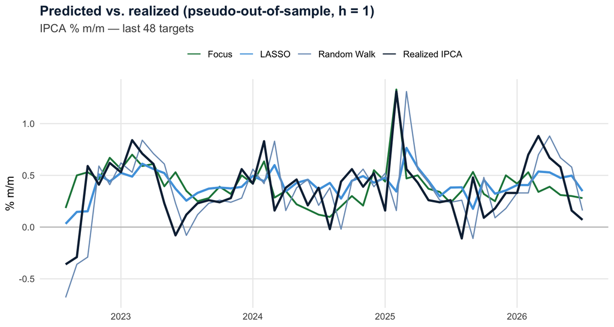

```r
p_oos <- tail(pred, 48) |>
  dplyr::select(target_date,
                `Realized IPCA` = y,
                `LASSO` = lasso,
                `Focus` = focus,
                `Random Walk` = rw) |>
  tidyr::pivot_longer(-target_date) |>
  ggplot(aes(target_date, value, color = name, linewidth = name)) +
  geom_hline(yintercept = 0, color = "grey75") +
  geom_line() +
  scale_color_manual(values = c(
    "Realized IPCA" = COR$tinta,
    "LASSO" = COR$claro,
    "Focus" = COR$verde,
    "Random Walk" = COR$cinza
  )) +
  scale_linewidth_manual(values = c(
    "Realized IPCA" = 1.1,
    "LASSO" = 1.1,
    "Focus" = 0.9,
    "Random Walk" = 0.6
  ), guide = "none") +
  labs(title = "Predicted vs. realized (pseudo-out-of-sample, h = 1)",
       subtitle = "IPCA % m/m — last 48 targets",
       x = NULL, y = "% m/m", color = NULL) +
  theme(legend.position = "top")
print(p_oos)
```

```r
ggsave("assets_en/fig3_oos.png", p_oos, width = 9, height = 4.8, dpi = 160)
```

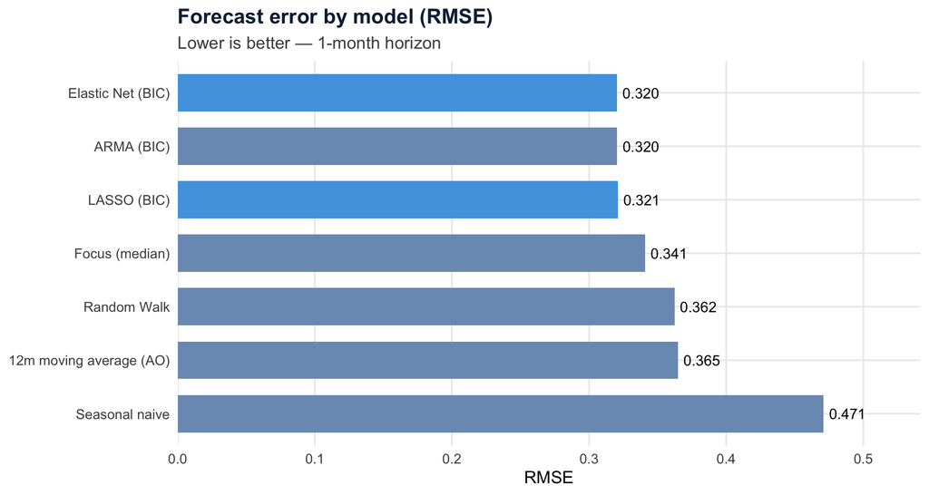

```r
p_rmse <- tab |>
  dplyr::mutate(model = reorder(model, -RMSE)) |>
  ggplot(aes(RMSE, model, fill = model %in% c("LASSO (BIC)", "Elastic Net (BIC)"))) +
  geom_col(width = 0.7) +
  geom_text(aes(label = scales::number(RMSE, accuracy = 0.001)),
            hjust = -0.15, size = 3.6) +
  scale_fill_manual(values = c(`TRUE` = COR$claro, `FALSE` = COR$cinza),
                    guide = "none") +
  scale_x_continuous(expand = expansion(mult = c(0, 0.15))) +
  labs(title = "Forecast error by model (RMSE)",
       subtitle = "Lower is better — 1-month horizon", x = "RMSE", y = NULL)
print(p_rmse)
```

```r
ggsave("assets_en/fig4_rmse.png", p_rmse, width = 9, height = 4.8, dpi = 160)
```

## 8.1 Performance across horizons

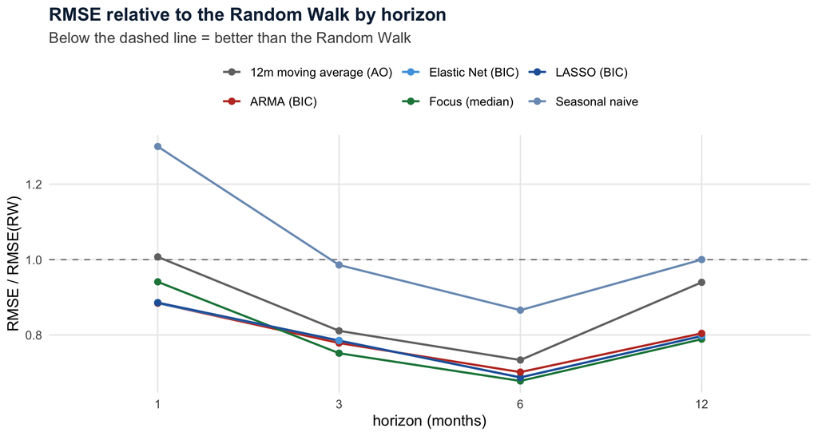

```r
# RMSE relative to the Random Walk by horizon: a line below 1 = better than RW.
p_rmse_h <- tab_all |>
  dplyr::filter(modelo_id != "rw") |>
  dplyr::mutate(h = factor(h, levels = HORIZONS)) |>
  ggplot(aes(h, RMSE_rel_RW, group = model, color = model)) +
  geom_hline(yintercept = 1, linetype = 2, color = "grey55") +
  geom_line(linewidth = 0.8) +
  geom_point(size = 2) +
  scale_color_manual(values = c(
    "LASSO (BIC)" = COR$azul,
    "Elastic Net (BIC)" = COR$claro,
    "ARMA (BIC)" = COR$vermelho,
    "Seasonal naive" = COR$cinza,
    "12m moving average (AO)" = "grey45",
    "Focus (median)" = COR$verde
  )) +
  labs(title = "RMSE relative to the Random Walk by horizon",
       subtitle = "Below the dashed line = better than the Random Walk",
       x = "horizon (months)", y = "RMSE / RMSE(RW)", color = NULL) +
  theme(legend.position = "top")
print(p_rmse_h)
```

```r
ggsave("assets_en/fig8_rmse_horizon.png", p_rmse_h,
       width = 9, height = 4.8, dpi = 160)
```

The reading is direct: the **Focus** is usually the lowest line (the hardest reference), and the interest is in how close LASSO and Elastic Net get to it — especially at the longer horizons, where the macro predictors have more room to add over pure inertia.

## 8.2 Where the gain appears over time: CSPE

We define the cumulative gain of LASSO over the Random Walk as

$$G_T = \sum_{t=1}^T
\left(e_{RW,t}^2-e_{LASSO,t}^2\right).$$

A rising curve indicates that, over that stretch, LASSO is accumulating a squared-error gain over the benchmark. We show the curve against the Random Walk and against the Focus — the latter is the more informative test, since it reveals in which episodes (and whether) the model competes with market expectations.

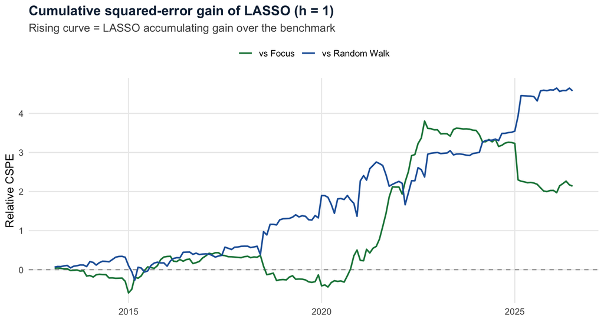

```r
cspe <- pred |>
  dplyr::transmute(
    target_date,
    `vs Random Walk` = cumsum((rw - y)^2 - (lasso - y)^2),
    `vs Focus` = cumsum(ifelse(is.finite(focus),
                               (focus - y)^2 - (lasso - y)^2, 0))
  ) |>
  tidyr::pivot_longer(-target_date, names_to = "benchmark",
                      values_to = "cum_gain")

p_cspe <- ggplot(cspe, aes(target_date, cum_gain, color = benchmark)) +
  geom_hline(yintercept = 0, linetype = 2, color = "grey60") +
  geom_line(linewidth = 0.8) +
  scale_color_manual(values = c("vs Random Walk" = COR$azul,
                                "vs Focus" = COR$verde)) +
  labs(title = "Cumulative squared-error gain of LASSO (h = 1)",
       subtitle = "Rising curve = LASSO accumulating gain over the benchmark",
       x = NULL, y = "Relative CSPE", color = NULL) +
  theme(legend.position = "top")
print(p_cspe)
```

```r
ggsave("assets_en/fig5_cspe.png", p_cspe, width = 9, height = 4.8, dpi = 160)
```

## 8.3 What LASSO selects — recursively

Importance is not the raw sum of coefficients. For each origin $t$ and predictor $j$, we use

$$I_{j,t} = |\hat\beta_{j,t}|\,sd_t(x_j),$$

that is, the absolute coefficient times the standard deviation of the predictor in the training window. We then aggregate importance across the out-of-sample origins.

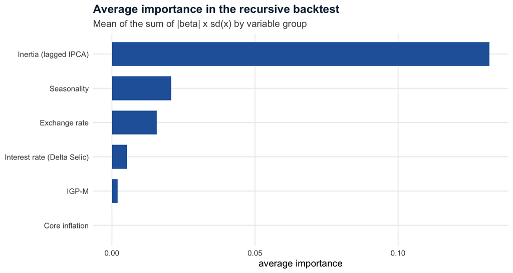

```r
group_of <- function(v) dplyr::case_when(
  grepl("^ipca_l", v)       ~ "Inertia (lagged IPCA)",
  grepl("^m[0-9]", v)       ~ "Seasonality",
  grepl("^cambio_dlog", v)  ~ "Exchange rate",
  grepl("^igpm", v)         ~ "IGP-M",
  grepl("^d_selic", v)      ~ "Interest rate (Delta Selic)",
  grepl("^nucleo", v)       ~ "Core inflation",
  TRUE ~ v
)

imp_grupo <- imp_rec |>
  dplyr::mutate(grupo = group_of(var)) |>
  dplyr::group_by(origin_date, grupo) |>
  dplyr::summarise(importance = sum(importance), .groups = "drop") |>
  dplyr::group_by(grupo) |>
  dplyr::summarise(
    mean_importance = mean(importance),
    .groups = "drop"
  )

p_imp <- ggplot(imp_grupo,
       aes(mean_importance, reorder(grupo, mean_importance))) +
  geom_col(fill = COR$azul, width = 0.7) +
  labs(title = "Average importance in the recursive backtest",
       subtitle = "Mean of the sum of |beta| x sd(x) by variable group",
       x = "average importance", y = NULL)
print(p_imp)
```

```r
ggsave("assets_en/fig6_importance.png", p_imp, width = 9, height = 4.8, dpi = 160)
```

Selection stability matters as much as coefficient size. The next chart shows in what share of the origins each lag received a non-zero coefficient.

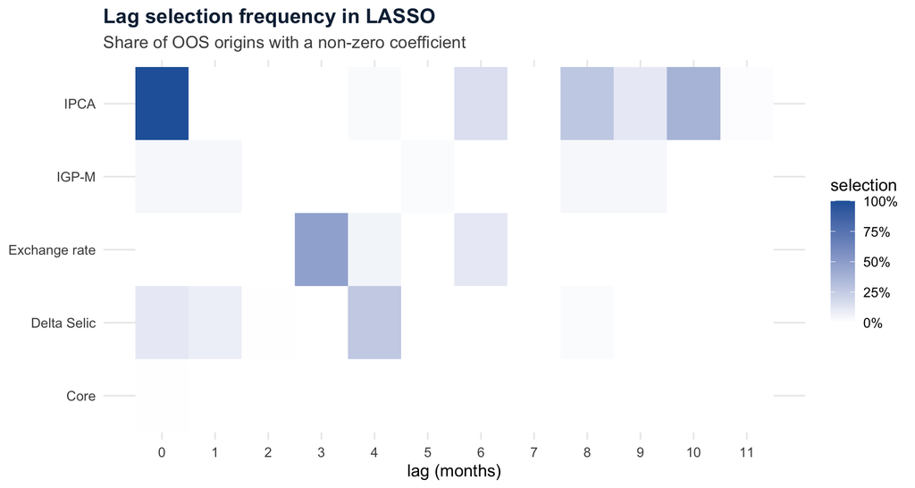

```r
sel_lags <- imp_rec |>
  dplyr::filter(grepl("_l[0-9]+$", var)) |>
  dplyr::mutate(
    base = sub("_l[0-9]+$", "", var),
    lag = as.integer(sub(".*_l", "", var)),
    base = dplyr::recode(base,
      ipca = "IPCA",
      cambio_dlog = "Exchange rate",
      d_selic = "Delta Selic",
      igpm = "IGP-M",
      nucleo = "Core"
    )
  ) |>
  dplyr::group_by(base, lag) |>
  dplyr::summarise(sel_freq = mean(selected), .groups = "drop")

p_sel <- ggplot(sel_lags, aes(lag, base, fill = sel_freq)) +
  geom_tile() +
  scale_x_continuous(breaks = 0:11) +
  scale_fill_gradient(low = "white", high = COR$azul,
                      labels = scales::percent_format(accuracy = 1)) +
  labs(title = "Lag selection frequency in LASSO",
       subtitle = "Share of OOS origins with a non-zero coefficient",
       x = "lag (months)", y = NULL, fill = "selection")
print(p_sel)
```

```r
ggsave("assets_en/fig7_selection_lags.png", p_sel, width = 9, height = 4.8, dpi = 160)
```

# 9 Conclusions and limitations

The final reading is conditioned on the numbers the specification actually produces. The object `tab` shows the RMSE/MAE ranking and `dm_tab` reports whether the accuracy differences are statistically detectable. For that reason, we avoid boilerplate claims such as “robust” or “not luck.”

The importance analysis is strictly **predictive**. The selection-frequency heatmap lets us check whether, for instance, particular exchange-rate lags are selected recurrently; no specific pass-through window is imposed a priori.

With the Focus and the four horizons in the horse race, the relevant question shifts from “does LASSO beat the Random Walk?” to “how close do LASSO and Elastic Net get to the Focus, and at which horizon?” The `tab_all` table and the relative-RMSE-by-horizon chart answer exactly that; `dm_all` reports in which comparisons the accuracy difference is statistically detectable.

**Limitations.** (i) latest-vintage data for the macro predictors, not a real-time base — this gives the models a mild informational advantage over the Focus, whose respondents saw only the data available at each survey date, so the model-vs-Focus comparison is, if anything, tilted slightly in the models’ favor; (ii) a deliberately small predictor set relative to the reference paper; (iii) direct, independent forecasting by horizon, without forecast combination; (iv) possible structural breaks, which may favor a rolling window in future exercises.

**Next steps.** Real-time vintages for the macro predictors; forecast combinations (for example, an average of LASSO, ARMA, and the Focus); rolling windows; and a sensitivity analysis for different numbers of lags.

Summary values at h = 1 to update the article.

| indicator | value |
| --- | --- |
| RMSE LASSO | 0.3210 |
| RMSE Elastic Net | 0.3204 |
| RMSE ARMA | 0.3205 |
| RMSE seasonal naive | 0.4710 |
| RMSE AO | 0.3649 |
| RMSE Random Walk | 0.3623 |
| RMSE Focus | 0.3409 |
| Gain LASSO vs RW (%) | 11.4120 |
| DM p one-sided: LASSO vs RW | 0.0139 |
| DM p two-sided: LASSO vs RW | 0.0278 |
| DM p one-sided: LASSO vs Focus | 0.1201 |
| DM p two-sided: LASSO vs Focus | 0.2402 |

Performance by horizon (all models).

| h | model | RMSE | RMSE_rel_RW | gain_pct_vs_RW |
| --- | --- | --- | --- | --- |
| 1 | Elastic Net (BIC) | 0.320 | 0.884 | 11.559 |
| 1 | ARMA (BIC) | 0.320 | 0.885 | 11.549 |
| 1 | LASSO (BIC) | 0.321 | 0.886 | 11.412 |
| 1 | Focus (median) | 0.341 | 0.941 | 5.906 |
| 1 | Random Walk | 0.362 | 1.000 | 0.000 |
| 1 | 12m moving average (AO) | 0.365 | 1.007 | -0.711 |
| 1 | Seasonal naive | 0.471 | 1.300 | -29.998 |
| 3 | Focus (median) | 0.361 | 0.752 | 24.844 |
| 3 | ARMA (BIC) | 0.374 | 0.779 | 22.138 |
| 3 | LASSO (BIC) | 0.377 | 0.785 | 21.497 |
| 3 | Elastic Net (BIC) | 0.377 | 0.785 | 21.483 |
| 3 | 12m moving average (AO) | 0.389 | 0.811 | 18.901 |
| 3 | Seasonal naive | 0.473 | 0.986 | 1.437 |
| 3 | Random Walk | 0.480 | 1.000 | 0.000 |
| 6 | Focus (median) | 0.374 | 0.678 | 32.199 |
| 6 | Elastic Net (BIC) | 0.379 | 0.687 | 31.267 |
| 6 | LASSO (BIC) | 0.379 | 0.687 | 31.266 |
| 6 | ARMA (BIC) | 0.387 | 0.701 | 29.857 |
| 6 | 12m moving average (AO) | 0.405 | 0.733 | 26.650 |
| 6 | Seasonal naive | 0.478 | 0.866 | 13.423 |
| 6 | Random Walk | 0.552 | 1.000 | 0.000 |
| 12 | Focus (median) | 0.383 | 0.789 | 21.111 |
| 12 | LASSO (BIC) | 0.387 | 0.797 | 20.304 |
| 12 | Elastic Net (BIC) | 0.387 | 0.798 | 20.243 |
| 12 | ARMA (BIC) | 0.390 | 0.804 | 19.574 |
| 12 | 12m moving average (AO) | 0.456 | 0.940 | 6.034 |
| 12 | Seasonal naive | 0.485 | 1.000 | 0.000 |
| 12 | Random Walk | 0.485 | 1.000 | 0.000 |

```
## File generated: article_medium_final_EN.md
```

*Data sources: Banco Central do Brasil / SGS and the Focus market-expectations survey (Olinda). Methodology inspired by Araujo & Gaglianone (BCB Working Paper 561, 2022). Personal study on public data; views are the author’s own.*